# Price Elasticity Estimation

Ngoc Linh Dao

2024-17-01

```r
options(repos = c(CRAN = "https://cloud.r-project.org"))
```

# Estimating Price Elasticities for Macroeconomic Data

```r
dat <- read.csv("chicken.csv")
```

Given model

$Y = ß_0 . income^{ß_1} . pchick^{ß_2} . pbeef^{ß_3}. ppork^{ß_4} . e$

## Task 1: Scatter plot for price of chicken versus demand for chicken

- Create scatter plot on original scale

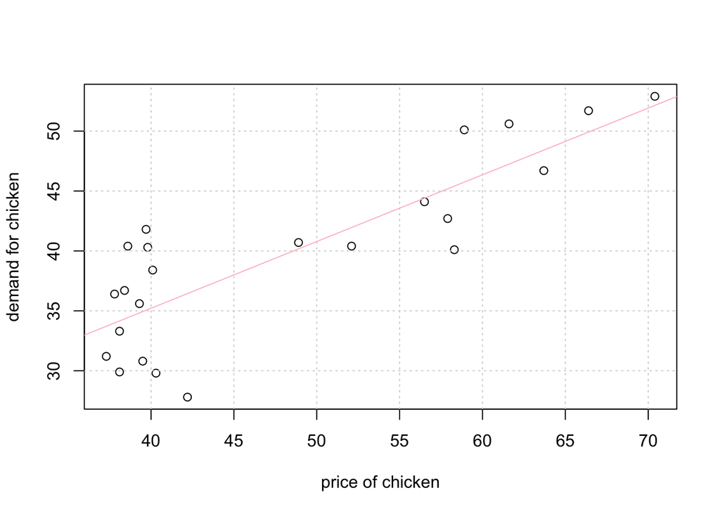

```r
plot1 <- plot(consum ~ pchick, xlab = 'price of chicken', ylab = 'demand for chicken', data = dat)
abline(lm(consum ~ pchick, data=dat), col = "pink")
grid()
```

- Create scatter plot on log-log scale

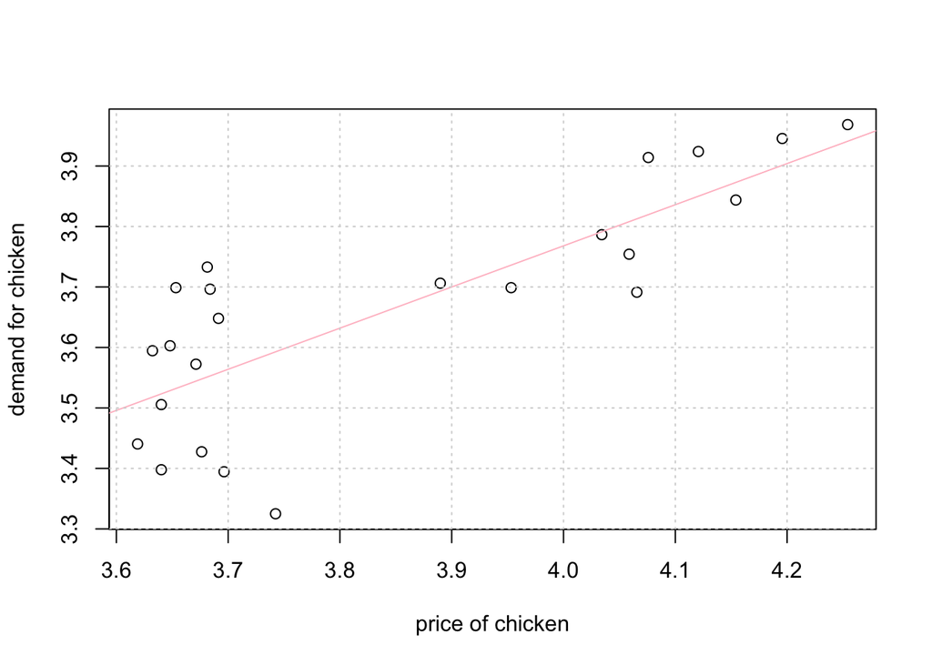

```r
plot2 <- plot(log(consum) ~ log(pchick), xlab = 'price of chicken', ylab = 'demand for chicken', data = dat)
abline(lm(log(consum)~log(pchick), data = dat), col = "pink")
grid()
```

**Comment:**

- In the case where we don’t take into account any other variables, we can see from the plot that the consumption increases as the price of chicken increases.
- On the original scales, the data are plotted as-is, according to the observed absolute values of dependent and independent variables.
- On the log-log scales, both the x-axis and y-axis are transformed using a logarithmic scale, emphasizing on the relative, rather than the absolute changes, of said variables.
- As seen on the scatter plots, the plot on original scale follows a similar pattern to that of the plot on the log-log scale, suggesting an exponential relationship between the variables as the relative changes are consistent with the absolute changes.
- However, due to the logarithmic transformation, the higher values are more compressed and the lower values expanded.

## Task 2: Rewrite the model in (1) as log Y = β0 + . . ..

$log(consum) = ß_0 + ß_1*log(income) + ß_2*log(pchick) + ß_3*log(pbeef) + ß_4*log(ppork) + u$

## Task 3: OLS Estimation

*a) OLS estimators*

```r
mod1<-lm(log(consum) ~ log(income) + log(pchick) + log(pbeef) + log(ppork) , data = dat)
summary(mod1)
```

```
##
## Call:
## lm(formula = log(consum) ~ log(income) + log(pchick) + log(pbeef) +
##     log(ppork), data = dat)
##
## Residuals:
##       Min        1Q    Median        3Q       Max
## -0.037877 -0.013242 -0.003969  0.010567  0.046636
##
## Coefficients:
##             Estimate Std. Error t value Pr(>|t|)
## (Intercept)  2.18979    0.15571  14.063 3.77e-11 ***
## log(income)  0.34256    0.08327   4.114 0.000652 ***
## log(pchick) -0.50459    0.11089  -4.550 0.000248 ***
## log(pbeef)   0.09110    0.10072   0.905 0.377643
## log(ppork)   0.14855    0.09967   1.490 0.153452
## ---
## Signif. codes:  0 '***' 0.001 '**' 0.01 '*' 0.05 '.' 0.1 ' ' 1
##
## Residual standard error: 0.02759 on 18 degrees of freedom
## Multiple R-squared:  0.9823, Adjusted R-squared:  0.9784
## F-statistic: 249.9 on 4 and 18 DF,  p-value: 1.667e-15
```

- Estimators of the model:

$log(Y) = 2.18979 + 0.34256*log(income) - 0.50459*log(pchick) + 0.09110*log(pbeef) + 0.14855*log(ppork)$

*b) The change of demand for chicken (consum) when the price of pork (ppork) rises by 1% on average, ceteris paribus*

The coefficient of log(ppork) = 0.14855

That means, that a 1% increase in price of pork leads to a 0.14855% increase on average in demand of chicken

*c) The change of demand for chicken (consum) when price of chicken (pchick) decreases by 3% on average, ceteris paribus*

The coefficient of log(pchick) = -0.50459

That means, that a 3% decrease in price of chicken leads to an expected change of a 1.51% increase in demand of chicken

## Task 4: Predict demand for chicken when the income = 2400, pchick = 52, ppork = 171.5, and pbeef = 313

```r
Y4<-2.18979 + 0.34256*log(2400) - 0.50459*log(52) + 0.09110*log(313) + 0.14855*log(171.5)
exp(Y4)
```

```
## [1] 63.43147
```

## Task 5: Coefficient of determination

*a) Compute sample correlation between fitted values and observations*

- Compute the correlation between fitted values and observed values

```r
y_hat <- fitted.values(mod1)
cor(y_hat,log(dat$consum))
```

```
## [1] 0.9911172
```

- Compute coefficient of determination R<sup>2</sup>

```r
R_squared <- cor(y_hat,log(dat$consum))^2
```

*b) Compute total sum of squares (TSS), regression sum of squares (RSS), sum of squared residuals (SSR)*

```r
y_mean <- mean(log(dat$consum))
print (y_mean)
```

```
## [1] 3.663887
```

- Compute total sum of squares:

```r
TSS <- sum(((log(dat$consum)-y_mean)^2))
print (TSS)
```

```
## [1] 0.7747529
```

- Compute regression sum of squares:

```r
RSS <- sum((fitted(mod1) - mean(log(dat$consum)))^2)
print (RSS)
```

```
## [1] 0.76105
```

- Compute sum of squared residuals:

```r
SSR <- sum(mod1$residuals^2)
print (SSR)
```

```
## [1] 0.01370284
```

- Double check if SSR + RSS sum up to TSS

```r
TSS_check = SSR + RSS
print (TSS_check)
```

```
## [1] 0.7747529
```

- Calculate R<sup>2</sup> again using R<sup>2</sup> = $RSS/TSS$ = $1 - (SSR/TSS)$

```r
RSS/TSS
```

```
## [1] 0.9823133
```

```r
k <- 4
n <- 23
Adjusted_Rsquared <- 1 - ((1 - R_squared) * (n - 1) / (n - k - 1))
```

*c) Find R<sup>2</sup> and Adjusted R<sup>2</sup> in summary*

```r
summary(mod1)$r.squared
```

```
## [1] 0.9823133
```

```r
summary(mod1)$adj.r.squared
```

```
## [1] 0.9783829
```

## Task 6: Statistical properties

*a) Compute the estimate of variance of residuals*

```r
summary(mod1)$sigma^2
```

```
## [1] 0.0007612687
```

*b) Put together covariance matrix of the OLS estimators of the parameters β1, . . . , β4*

```r
vcov(mod1)
cov2cor(vcov(mod1))
```

```
##              (Intercept)  log(income)  log(pchick)   log(pbeef)   log(ppork)
## (Intercept)  0.024247119 -0.006559234 -0.015165454  0.007158685  0.010060694
## log(income) -0.006559234  0.006933278  0.005771445 -0.007055636 -0.006575017
## log(pchick) -0.015165454  0.005771445  0.012297538 -0.007322699 -0.008232352
## log(pbeef)   0.007158685 -0.007055636 -0.007322699  0.010143805  0.004664088
## log(ppork)   0.010060694 -0.006575017 -0.008232352  0.004664088  0.009934626
##             (Intercept) log(income) log(pchick) log(pbeef) log(ppork)
## (Intercept)   1.0000000  -0.5058873  -0.8782462  0.4564600  0.6482195
## log(income)  -0.5058873   1.0000000   0.6250376 -0.8413301 -0.7922310
## log(pchick)  -0.8782462   0.6250376   1.0000000 -0.6556342 -0.7447990
## log(pbeef)    0.4564600  -0.8413301  -0.6556342  1.0000000  0.4646121
## log(ppork)    0.6482195  -0.7922310  -0.7447990  0.4646121  1.0000000
```

## Task 7: Single coefficient test: State null hypothesis, significance level, test statistic, p value, and their interpretation

```r
summary(mod1)
```

```
##
## Call:
## lm(formula = log(consum) ~ log(income) + log(pchick) + log(pbeef) +
##     log(ppork), data = dat)
##
## Residuals:
##       Min        1Q    Median        3Q       Max
## -0.037877 -0.013242 -0.003969  0.010567  0.046636
##
## Coefficients:
##             Estimate Std. Error t value Pr(>|t|)
## (Intercept)  2.18979    0.15571  14.063 3.77e-11 ***
## log(income)  0.34256    0.08327   4.114 0.000652 ***
## log(pchick) -0.50459    0.11089  -4.550 0.000248 ***
## log(pbeef)   0.09110    0.10072   0.905 0.377643
## log(ppork)   0.14855    0.09967   1.490 0.153452
## ---
## Signif. codes:  0 '***' 0.001 '**' 0.01 '*' 0.05 '.' 0.1 ' ' 1
##
## Residual standard error: 0.02759 on 18 degrees of freedom
## Multiple R-squared:  0.9823, Adjusted R-squared:  0.9784
## F-statistic: 249.9 on 4 and 18 DF,  p-value: 1.667e-15
```

*a) Does the price of pork have a significant impact on the demand for chicken?*

**H0 = The variable ppork has no impact on consum (demand of chicken) ceteris paribus**

**H1 = The variable ppork has significant impact on the demand for chicken**

- Significance level = 0.05

*Interpretation: There is always probability of rejecting the null hypothesis when it is indeed true (type I error), therefore, the significance level acts like a kind of threshold to help make the decision of whether or not the null hypothesis should be kept or rejected. When the p-value is bigger than the significant level, this means that there are more than 5% of committing the mentioned type I error, meaning the null hypothesis should NOT be rejected in such a case.*

- test statistic: t-value = 1.490

*Interpretation: the farther away the estimated coefficient is from 0, and the more likely it is to be statistically significant. For the decision to be more precise, we will compare the absolute value of t to the critical value from the t-distribution table*

- degree of freedom = n - ncol = 23 - 4 - 1 = 18
- critical value from t-distribution table is 2.101
- |t| < c ->

*Interpretation: do NOT reject H0 -> the impact of ppork on consum might not be significant*

- p-value: 0.153452

*Interpretation: a measure to help you determine statistical significance. In this case, we have p-value = 0.15, which is bigger than the significance level and therefore, we can NOT reject the null hypothesis, meaning, again, the impact of price of pork on demand of chicken is not significant.*

*b) Does the income have a significant impact on the demand for chicken?*

**H0 = The variable income has no impact on the demand of chicken, ceteris paribus**

**H1 = The variable income has a significant impact on demand of chicken, ceteris paribus**

- Significance level = 0.05
- test statistic: t-value 4.114
- |t| > c

*Interpretation: reject H0 -> accept H1 -> the variable has significant impact on dependent variable*

- p-value: 0.000652

*Interpretation: p-value is < threshold of significance and very small, therefore, the impact of variable income is statistically significant*

## Task 8: Multiple Coefficient Test: State null hypothesis, significance level, test statistic, p value, and their interpretation

*a) Determine the impact of Price of beef AND Price of Pork on Demand for chicken*

```r
library('carData')
library('car')
```

**H0 = The variables price of pork and price of beef have no impact on the demand of chicken, ceteris paribus -> all coefficients are equal to 0**

**H1 = at least one of the variables has a significant impact -> at least one of the coefficients of the variables is ≠ 0**

*Interpretation: p > significance level, therefore, probability of committing type I error is larger than the accepted level , meaning we can NOT reject H0, meaning none of the two variables (ppork and pbeef) are statistically significant*

**Conclusion : Neither price of pork and price of beef have a significant impact on the demand of chicken, meaning we could take both of them out of the model.**

*b) Determine the impact of income AND price of Pork on demand for chicken*

```r
linearHypothesis(mod1, c("log(income) = 0", "log(ppork) = 0"))
```

```
##
## Linear hypothesis test:
## log(income) = 0
## log(ppork) = 0
##
## Model 1: restricted model
## Model 2: log(consum) ~ log(income) + log(pchick) + log(pbeef) + log(ppork)
##
##   Res.Df      RSS Df Sum of Sq      F    Pr(>F)
## 1     20 0.072705
## 2     18 0.013703  2  0.059002 38.752 3.001e-07 ***
## ---
## Signif. codes:  0 '***' 0.001 '**' 0.01 '*' 0.05 '.' 0.1 ' ' 1
```

**H0 = The variables price of pork and income both have no impact on demand of chicken, ceteris paribus -> all coefficients are equal to 0**

**H1 = at least one of the variables has a significant impact -> at least one of the coefficients of the variables is ≠ 0**

- Significance level = 0.05
- F-test statistic: F-value = 38.752
- F > c

*Interpretation: reject H0*

- p-value: 3.001e-07

*Interpretation: p-value < significance level, therefore, we can reject H0, meaning at least one of the two variables (ppork and income) is significant.*

**Conclusion: we can not take both of them out of the model at the same time -> individual t-tests have to be conducted to find out which variable has significant impact.**

*c) Determine the impact of all variables on demand for chicken*

```r
linearHypothesis(mod1, c("log(income) = 0", "log(pchick) = 0","log(pbeef) = 0", "log(ppork) = 0"))
```

```
##
## Linear hypothesis test:
## log(income) = 0
## log(pchick) = 0
## log(pbeef) = 0
## log(ppork) = 0
##
## Model 1: restricted model
## Model 2: log(consum) ~ log(income) + log(pchick) + log(pbeef) + log(ppork)
##
##   Res.Df     RSS Df Sum of Sq      F    Pr(>F)
## 1     22 0.77475
## 2     18 0.01370  4   0.76105 249.93 1.667e-15 ***
## ---
## Signif. codes:  0 '***' 0.001 '**' 0.01 '*' 0.05 '.' 0.1 ' ' 1
```

**H0 = All variables have no impact on demand of chicken -> all coefficients are equal to 0**

**H1 = At least one of the variables has a significant impact -> at least one of the coefficients of the variables is ≠ 0**

- Significance level = 0.05
- F-test statistic: f-value = 249.93

*Interpretation: F > c -> reject the H0*

- p-value: 1.667e-15

*Interpretation: p-value < significance level, therefore, we reject H0, meaning at least one of all variables is significant.*

**Conclusion: we can not take all of them out of the model at the same time ->** **individual t-tests have to be conducted to find out which variable has significant impact.**

## Task 9: Quantification of the influence of disposable income, determine 99% confidence interval for the appropriate elasticity.

*a) Quantification of the influence of disposable income*

- Since we have a linear model (linear in parameters), the influence of income can be quantified using the estimated coefficient for log(income)

  ```
  0.34256
  ```

  , meaning a 1% increase in Income leads to an average 0.34% increase in the consumption of chicken, ceteris paribus.
- Another way would be to measure the difference at two different income levels and calculate the change in %. That should lead to the same result:

```r
newdata <- list(income= c(500, 505),pchick=c(100,100),pbeef=c(100,100),ppork=c(100,100))
pred<-exp(predict(mod1, newdata))
print(pred)
```

```
##        1        2
## 22.16545 22.24113
```

```r
100*diff(log(pred))
```

```
##         2
## 0.3408537
```

- z-score computed with z-score table:
  - Al = (1+CL)/2
  - (1+0.99)/2
  - check table for corresponding row and column: row = 2.5, column = 0.075: z<-2.5+0.075 = 2.575
- z-score computed in R

  ```r
  z<-qnorm(0.995)
  print (z)
  ```

  ```
  ## [1] 2.575829
  ```

  ```r
  x<-log(dat$income)
  n<-length(x)
  mean_x<-mean(x)
  sd_x<-sd(x)
  ```

  ```r
  error<-z*sd_x/sqrt(n)
  ```

- Determine the lower bound of 99% confidence interval

  ```r
  mean_x - error
  ```

  ```
  ## [1] 6.477271
  ```

- Determine the upper bound of 99% confidence interval

  ```r
  mean_x + error
  ```

  ```
  ## [1] 7.089637
  ```

**Conclusion: We are 99% confident that the true parameter of the mean of log(income) falls within the interval from 6.48 to 7.09.**

## Task 10: Fit to simple regression models $Y=α_0*income^{a_1}$ , and $Y = α_0*pchick^{α2}$, compare α and ß

```r
mod1.10a<-lm(log(consum)~log(income), data=dat)
mod1.10b<-lm(log(consum)~log(pchick), data=dat)
```

```r
summary(mod1.10a)
```

```
##
## Call:
## lm(formula = log(consum) ~ log(income), data = dat)
##
## Residuals:
##       Min        1Q    Median        3Q       Max
## -0.083293 -0.031699 -0.005465  0.040507  0.079572
##
## Coefficients:
##             Estimate Std. Error t value Pr(>|t|)
## (Intercept)  1.49221    0.11382   13.11 1.40e-11 ***
## log(income)  0.32014    0.01672   19.14 8.98e-15 ***
## ---
## Signif. codes:  0 '***' 0.001 '**' 0.01 '*' 0.05 '.' 0.1 ' ' 1
##
## Residual standard error: 0.04471 on 21 degrees of freedom
## Multiple R-squared:  0.9458, Adjusted R-squared:  0.9432
## F-statistic: 366.5 on 1 and 21 DF,  p-value: 8.976e-15
```

```r
summary(mod1.10b)
```

```
##
## Call:
## lm(formula = log(consum) ~ log(pchick), data = dat)
##
## Residuals:
##      Min       1Q   Median       3Q      Max
## -0.26777 -0.06112  0.01314  0.07544  0.18165
##
## Coefficients:
##             Estimate Std. Error t value Pr(>|t|)
## (Intercept)   1.0461     0.4226   2.475   0.0219 *
## log(pchick)   0.6805     0.1097   6.204 3.73e-06 ***
## ---
## Signif. codes:  0 '***' 0.001 '**' 0.01 '*' 0.05 '.' 0.1 ' ' 1
##
## Residual standard error: 0.1141 on 21 degrees of freedom
## Multiple R-squared:  0.647,  Adjusted R-squared:  0.6302
## F-statistic: 38.49 on 1 and 21 DF,  p-value: 3.733e-06
```

```r
summary(mod1)
```

```
##
## Call:
## lm(formula = log(consum) ~ log(income) + log(pchick) + log(pbeef) +
##     log(ppork), data = dat)
##
## Residuals:
##       Min        1Q    Median        3Q       Max
## -0.037877 -0.013242 -0.003969  0.010567  0.046636
##
## Coefficients:
##             Estimate Std. Error t value Pr(>|t|)
## (Intercept)  2.18979    0.15571  14.063 3.77e-11 ***
## log(income)  0.34256    0.08327   4.114 0.000652 ***
## log(pchick) -0.50459    0.11089  -4.550 0.000248 ***
## log(pbeef)   0.09110    0.10072   0.905 0.377643
## log(ppork)   0.14855    0.09967   1.490 0.153452
## ---
## Signif. codes:  0 '***' 0.001 '**' 0.01 '*' 0.05 '.' 0.1 ' ' 1
##
## Residual standard error: 0.02759 on 18 degrees of freedom
## Multiple R-squared:  0.9823, Adjusted R-squared:  0.9784
## F-statistic: 249.9 on 4 and 18 DF,  p-value: 1.667e-15
```

Coefficient of var. income

Coefficient of var. pchick

**Model 1.10a (α1)**

```
 0.32014
```

-

**Model 1.10b (α2)**

-

[output not shown]

**Full model 1**

```
0.34256
```

```
-0.50459
```

**Comparison:**

- *α1 compared to ß1*: In terms of simple model 10a, the coefficients are pretty similar for the log-log model. It is, therefore, a good model to explain the relationship between the income and the demand for chicken.
- *α2 compared to ß2*:
  - There is a positive coefficient for variable price of chicken, which would indicate that when the price goes up, consumption goes up, which does not make sense in the real world. This is the reason why simple model 10b is not a good model.
  - In the full model, the influence of income was factored into the model, which then produced an effect on the coefficient of variable price of chicken (which makes sense in the real world, since whether or not prices matter depends largely on income), making it a negative coefficient, and thus, makes mod1 a better model to explain the relationship between the price of chicken and the demand for chicken.